# Statistical data analysis

Boca et al

## Load all libraries and functions

```r
library(ggplot2)
library(RColorBrewer)
library(corrplot)
source("functions.R")
```

## Load data

```r
load("../objs/MasterFrame.RData")
```

## Compare DMD cases and healthy controls considering the effects of age and study site

Fit a linear model with transformed metabolite intensities as outcomes, regressing on DMD status, age, their interaction, and study site. Compare it to a model which has just age and study center, testing whether the coefficients of DMD and of DMD x age are 0. Thus, the test is to see whether there is any effect of DMD on the intensities in the presence of age.

```r
##get p-values for testing whether there is any effect of DMD
##(so compare this model to just a model for age and study center)
pValsAnyDMD <- vapply(MasterFrame[,mets],
                      function(metInt, status, age, site){
                        ##interaction model
                        lm.metInt <- lm(metInt ~ status*age + as.factor(site));
                        ##age-only model
                        lm.metAge <- lm(metInt ~ age + as.factor(site));
                        anova(lm.metInt, lm.metAge)["Pr(>F)"][2,1]
                      },
                      FUN.VALUE = 0.1,
                      MasterFrame$Status,
                      MasterFrame$Age,
                      MasterFrame$Site)
```

### Find top peaks

Now look at how many of the peaks have q-values less than or equal to 0.05 and 0.01 (use just the 0.01 moving forward), so that the false discovery rate is controlled at 0.05 and 0.01, as well as how many peaks are significant at a Bonferroni-corrected threshold of 0.05:

```r
qValsAnyDMD <- p.adjust(pValsAnyDMD, method="BH")
length(qValsAnyDMD)
```

```
## [1] 2203
```

```r
sum(qValsAnyDMD <= 0.05)
```

```
## [1] 37
```

```r
sum(qValsAnyDMD <= 0.01)
```

```
## [1] 14
```

```r
topFDRpeaks <- names(which(qValsAnyDMD <= 0.01))
##sort the top peaks by the p-values
topFDRpeaks <- topFDRpeaks[order(pValsAnyDMD[topFDRpeaks])]
topFDRpeaks
```

```
##  [1] "M357T30p"  "M369T366n" "M114T37p"  "M367T347n" "M312T36p"
##  [6] "M132T37p"  "M451T372p" "M270T359p" "M397T369n" "M174T37p"
## [11] "M449T366n" "M357T41n"  "M209T321p" "M432T331p"
```

```r
topFWERpeaks <- names(which(pValsAnyDMD <= 0.05/length(pValsAnyDMD)))
##sort them by p-value, from lowest to highest
topFWERpeaks <- topFWERpeaks[order(pValsAnyDMD[topFWERpeaks])]
topFWERpeaks
```

```
## [1] "M357T30p"  "M369T366n" "M114T37p"  "M367T347n" "M312T36p"  "M132T37p"
## [7] "M451T372p" "M270T359p"
```

### Make plots for top peaks

Make some nice plots for them. Generate both boxplots and plots versus age (they are actually displayed later):

```r
##save all the top plots in list
ggTop <- list()
##also save all boxplots in list
ggTopBox <- list()
##get all sites
sites <- levels(MasterFrame$Site)
nrSites <- length(sites)
for(met in topFDRpeaks)
{
  lmMet <- lm(MasterFrame[,met] ~
                MasterFrame[,"Status"]*MasterFrame[,"Age"]+as.factor(MasterFrame[,"Site"]),
              data=MasterFrame)
  lmMet

  pred <- predict(lmMet)

  ##get the linear model predictions for Calgary controls and DMD
  whichCalgContr <- which(MasterFrame$Site == "Calgary" &
                            MasterFrame$Status == "Control")
  whichCalgDMD <- which(MasterFrame$Site == "Calgary" &
                          MasterFrame$Status == "DMD")
  predCalgContr <- cbind(MasterFrame$Age[whichCalgContr],
                         pred[whichCalgContr])
  predCalgDMD <- cbind(MasterFrame$Age[whichCalgDMD],
                       pred[whichCalgDMD])

  ##get the linear model predictions for the Davis group (only DMD)
  whichDavis <- which(MasterFrame$Site == "UC Davis")
  predDavis <- cbind(MasterFrame$Age[whichDavis],
                     pred[whichDavis])

  ##get the values for min and max age for these groups (to plot the segments)
  CalgDMDseg <- matrix(c(min(predCalgDMD[,1]),
                         predCalgDMD[which.min(predCalgDMD[,1]),2],
                         max(predCalgDMD[,1]),
                         predCalgDMD[which.max(predCalgDMD[,1]),2]),
                       nrow=2, byrow=TRUE)
  CalgContrSeg <- matrix(c(min(predCalgContr[,1]),
                           predCalgContr[which.min(predCalgContr[,1]),2],
                           max(predCalgContr[,1]),
                           predCalgContr[which.max(predCalgContr[,1]),2]),
                         nrow=2, byrow=TRUE)
  DavisDMDseg <- matrix(c(min(predDavis[,1]),
                          predDavis[which.min(predDavis[,1]),2],
                          max(predDavis[,1]),
                          predDavis[which.max(predDavis[,1]),2]),
                        nrow=2, byrow=TRUE)
  segs <- data.frame(Site = c("Calgary", "Calgary", "UC Davis"),
                     Status = c("DMD", "Control", "DMD"),
                     x = c(CalgDMDseg[1,1], CalgContrSeg[1,1], DavisDMDseg[1,1]),
                     y = c(CalgDMDseg[1,2], CalgContrSeg[1,2], DavisDMDseg[1,2]),
                     xend = c(CalgDMDseg[2,1], CalgContrSeg[2,1], DavisDMDseg[2,1]),
                     yend = c(CalgDMDseg[2,2], CalgContrSeg[2,2], DavisDMDseg[2,2]))

  ggTop[[met]] <- ggplot(MasterFrame, aes_string(x="Age", y=met, shape="Status", color="Status")) +
    geom_point(size=2.5) +
    geom_segment(data=segs, aes(x=x, y=y,
                                xend=xend, yend=yend,
                                linetype=Site),
                 size=1.1) +
    scale_color_manual(name = "Class",
                       breaks = c("Control", "DMD"),
                       labels = c("Control", "DMD"),
                       values = c(4,2)) +
    scale_shape_manual(name = "Class",
                       breaks = c("Control", "DMD"),
                       labels = c("Control", "DMD"),
                       values = c(1,2)) +
    scale_y_continuous(name="Normalized intensity") +
    labs(title=(paste(met, ", ",
                      "p-value: ", signif(pValsAnyDMD[met],2), ", ",
                      "q-value: ", signif(qValsAnyDMD[met],2),
                      sep=""))) +
    theme(plot.title = element_text(size = 15, hjust = 0.2, vjust=1.5),
          legend.title = element_text(size = 14),
          legend.text = element_text(size=14),
          axis.title = element_text(size=14))

  ggTopBox[[met]] <- ggplot(MasterFrame, aes_string(x="Status", y=met))+
    geom_boxplot() +
    geom_point(size=3.0, aes(color=Category)) +
    scale_y_continuous(name="Normalized intensity") +
    labs(title=met) +
    scale_color_discrete(name = "Age category") +
    theme(plot.title = element_text(size = 15, hjust = 0.2, vjust=1.5),
          legend.title = element_text(size = 14),
          legend.text = element_text(size=14),
          axis.title = element_text(size=14))
}
```

### Display plots versus age for top peaks

Plots of the intensities versus age, including some of the fitted regression lines, coded by case/control status:

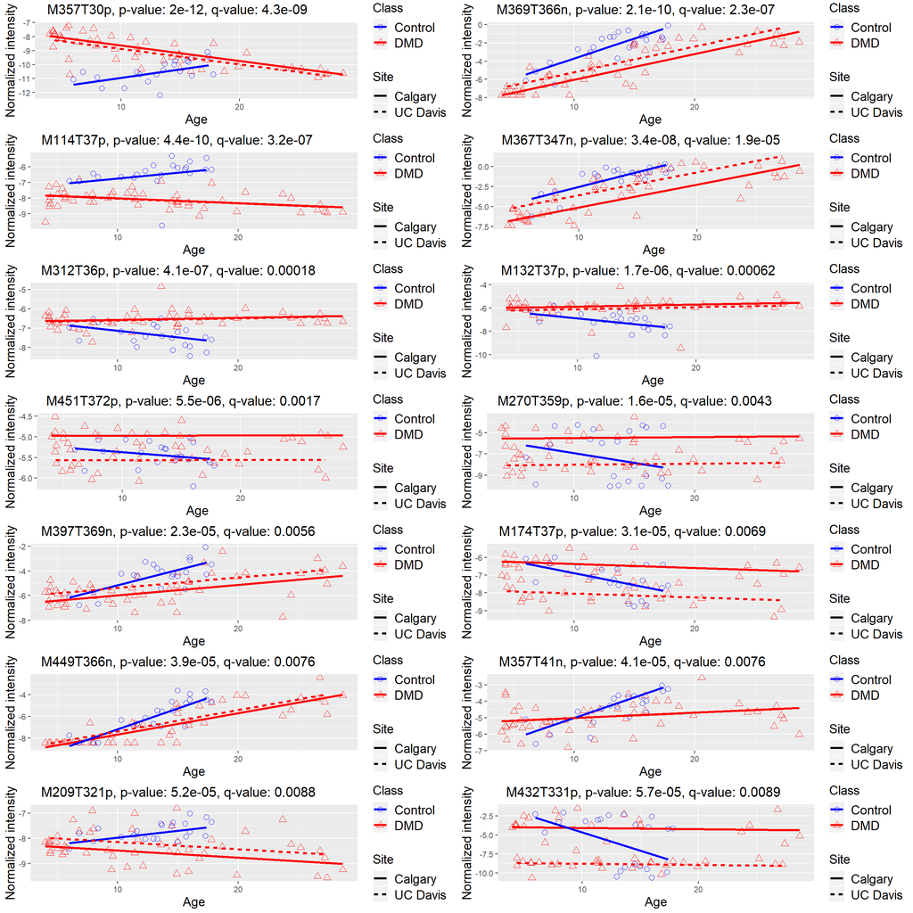

```r
multiplot(plotlist=ggTop, layout=matrix(1:length(ggTop), ncol=2, byrow=TRUE))
```

### Display boxplots for case/control status for top peaks

Boxplots of the intensities versus case control status, color-coded by age category:

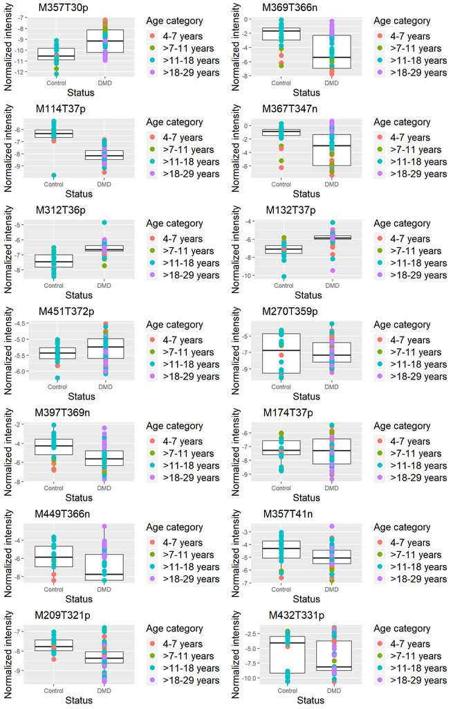

```r
multiplot(plotlist=ggTopBox, layout=matrix(1:length(ggTopBox), ncol=2, byrow=TRUE))
```

### Correlation plot for top peaks

Also calculate and plot the correlations between the top peaks:

```r
##make it in matrix version as well:
cor.matrix <- matrix(NA, length(topFDRpeaks), length(topFDRpeaks))

for(i1 in 1:length(topFDRpeaks))
{
  for(i2 in 1:length(topFDRpeaks))
  {
    Met1 <- topFDRpeaks[i1]
    Met2 <- topFDRpeaks[i2]

    cor.matrix[i1, i2] <-
      cor(MasterFrame[, Met1], MasterFrame[, Met2])
  }
}
rownames(cor.matrix) <- colnames(cor.matrix) <- topFDRpeaks

round(cor.matrix, 2)
```

```
##           M357T30p M369T366n M114T37p M367T347n M312T36p M132T37p
## M357T30p      1.00     -0.60    -0.24     -0.57     0.18     0.24
## M369T366n    -0.60      1.00     0.24      0.92    -0.32    -0.33
## M114T37p     -0.24      0.24     1.00      0.17    -0.52    -0.48
## M367T347n    -0.57      0.92     0.17      1.00    -0.27    -0.30
## M312T36p      0.18     -0.32    -0.52     -0.27     1.00     0.74
## M132T37p      0.24     -0.33    -0.48     -0.30     0.74     1.00
## M451T372p     0.17     -0.14    -0.12     -0.21     0.28     0.19
## M270T359p     0.06     -0.18     0.05     -0.19    -0.01    -0.06
## M397T369n    -0.37      0.72     0.20      0.76    -0.37    -0.42
## M174T37p      0.10     -0.30     0.07     -0.33     0.02     0.05
## M449T366n    -0.48      0.88     0.13      0.83    -0.23    -0.23
## M357T41n     -0.06      0.51     0.25      0.41    -0.01    -0.12
## M209T321p     0.03      0.19     0.49      0.13    -0.36    -0.40
## M432T331p     0.01     -0.19     0.18     -0.25    -0.06     0.00
##           M451T372p M270T359p M397T369n M174T37p M449T366n M357T41n
## M357T30p       0.17      0.06     -0.37     0.10     -0.48    -0.06
## M369T366n     -0.14     -0.18      0.72    -0.30      0.88     0.51
## M114T37p      -0.12      0.05      0.20     0.07      0.13     0.25
## M367T347n     -0.21     -0.19      0.76    -0.33      0.83     0.41
## M312T36p       0.28     -0.01     -0.37     0.02     -0.23    -0.01
## M132T37p       0.19     -0.06     -0.42     0.05     -0.23    -0.12
## M451T372p      1.00      0.48     -0.13     0.74     -0.08     0.13
## M270T359p      0.48      1.00     -0.18     0.57     -0.12    -0.16
## M397T369n     -0.13     -0.18      1.00    -0.23      0.74     0.34
## M174T37p       0.74      0.57     -0.23     1.00     -0.23    -0.11
## M449T366n     -0.08     -0.12      0.74    -0.23      1.00     0.52
## M357T41n       0.13     -0.16      0.34    -0.11      0.52     1.00
## M209T321p      0.00     -0.08      0.10    -0.01      0.07     0.32
## M432T331p      0.57      0.69     -0.24     0.77     -0.17    -0.11
##           M209T321p M432T331p
## M357T30p       0.03      0.01
## M369T366n      0.19     -0.19
## M114T37p       0.49      0.18
## M367T347n      0.13     -0.25
## M312T36p      -0.36     -0.06
## M132T37p      -0.40      0.00
## M451T372p      0.00      0.57
## M270T359p     -0.08      0.69
## M397T369n      0.10     -0.24
## M174T37p      -0.01      0.77
## M449T366n      0.07     -0.17
## M357T41n       0.32     -0.11
## M209T321p      1.00      0.06
## M432T331p      0.06      1.00
```

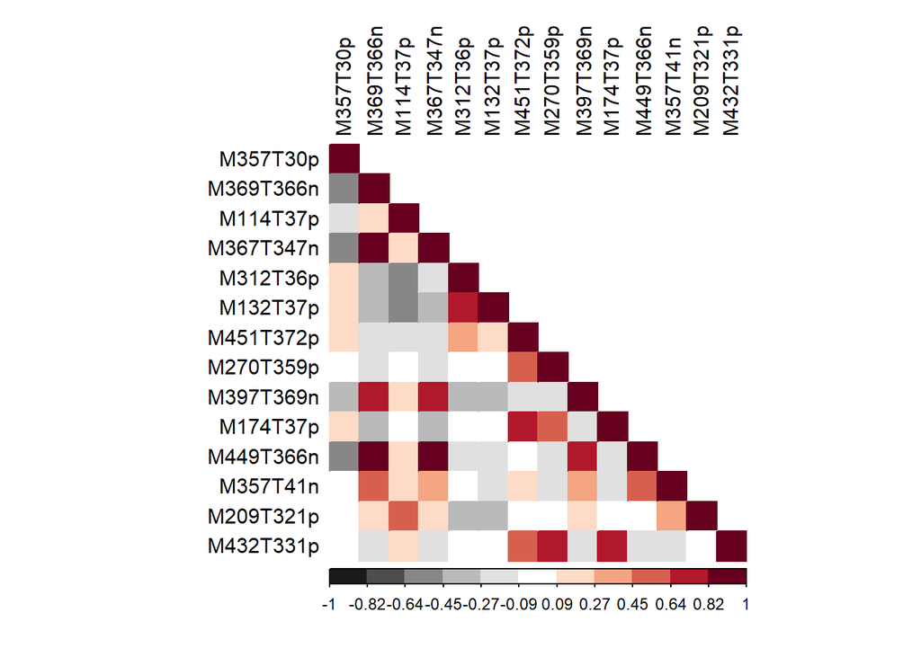

```r
par(mar=c(17,16,0.5,0.5)+0.1, oma=c(1,1,1,1),
    cex = 0.95)
corrplot(round(cor.matrix,2), col=rev(brewer.pal(11, "RdGy")),##[c(1,3,5,6,7,9,11)]),
         method="color",
         tl.pos="lt",
         type="lower", tl.col="black")
```